# Exercise solutions: Section 10.7

Author

Rob J Hyndman and George Athanasopoulos

# fpp3 10.7, Ex 1

> This exercise uses data set `LakeHuron` giving the level of Lake Huron from 1875–1972.
> 1. Convert the data to a tsibble object using the `as_tsibble()` function.
> 2. Fit a piecewise linear trend model to the Lake Huron data with a knot at 1920 and an ARMA error structure.
> 3. Forecast the level for the next 30 years. Do you think the extrapolated linear trend is realistic?

```r
huron <- as_tsibble(LakeHuron)
fit <- huron |>
  model(ARIMA(value ~ trend(knot = 1920)))
report(fit)
```

```
Series: value
Model: LM w/ ARIMA(2,0,0) errors

Coefficients:
         ar1      ar2  trend(knot = 1920)trend  trend(knot = 1920)trend_46
      0.9628  -0.3107                  -0.0572                      0.0633
s.e.  0.0973   0.0983                   0.0161                      0.0265
      intercept
       580.9391
s.e.     0.5124

sigma^2 estimated as 0.4594:  log likelihood=-98.86
AIC=209.73   AICc=210.65   BIC=225.24
```

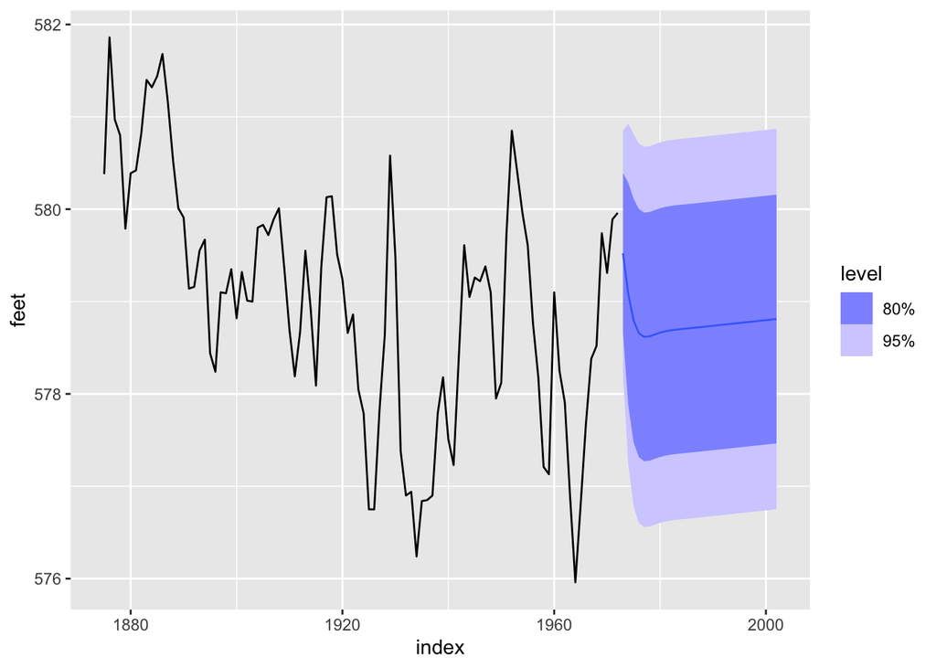

```r
fit |>
  forecast(h = 30) |>
  autoplot(huron) + labs(y = "feet")
```

It seems unlikely that there was an increasing trend from 1973 to 2002, but the prediction intervals are very wide so they probably capture the actual values. Historical data on the level of Lake Huron can be obtained from the [NOAA](https://tidesandcurrents.noaa.gov/waterlevels.html?id=9075014&bdate=19730101&edate=20020101&datum=IGLD&interval=m&action=data).

# fpp3 10.7, Ex 2

> Repeat Exercise 4 from Section 7.10, but this time adding in ARIMA errors to address the autocorrelations in the residuals.
> 1. How much difference does the ARIMA error process make to the regression coefficients?

```r
fit <- souvenirs |>
  mutate(festival = month(Month) == 3 & year(Month) != 1987) |>
  model(
    reg = TSLM(log(Sales) ~ trend() + season() + festival),
    dynreg = ARIMA(log(Sales) ~ trend() + season() + festival)
  )
tidy(fit) |> print(n=50)
```

```
# A tibble: 31 × 6
   .model term           estimate std.error statistic  p.value
   <chr>  <chr>             <dbl>     <dbl>     <dbl>    <dbl>
 1 reg    (Intercept)      7.62    0.0742     103.    4.67e-78
 2 reg    trend()          0.0220  0.000827    26.6   2.32e-38
 3 reg    season()year2    0.251   0.0957       2.63  1.06e- 2
 4 reg    season()year3    0.266   0.193        1.38  1.73e- 1
 5 reg    season()year4    0.384   0.0957       4.01  1.48e- 4
 6 reg    season()year5    0.409   0.0957       4.28  5.88e- 5
 7 reg    season()year6    0.449   0.0958       4.69  1.33e- 5
 8 reg    season()year7    0.610   0.0958       6.37  1.71e- 8
 9 reg    season()year8    0.588   0.0959       6.13  4.53e- 8
10 reg    season()year9    0.669   0.0959       6.98  1.36e- 9
11 reg    season()year10   0.747   0.0960       7.79  4.48e-11
12 reg    season()year11   1.21    0.0960      12.6   1.29e-19
```

[output cut: 19 more lines]

The coefficients are all relatively close.

> 2. How much difference does the ARIMA error process make to the forecasts?

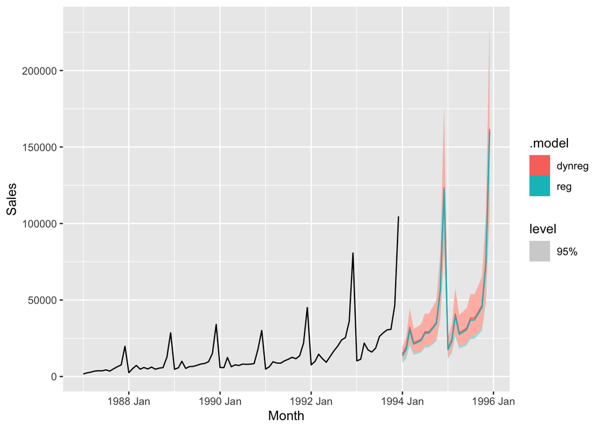

```r
future_souvenirs <- new_data(souvenirs, n = 24) |>
  mutate(festival = month(Month) == 3)
fit |>
  forecast(new_data = future_souvenirs)  |>
  autoplot(souvenirs, level=95)
```

The forecasts are also extremely close.

> 3. Check the residuals of the fitted model to ensure the ARIMA process has adequately addressed the autocorrelations seen in the `TSLM` model.

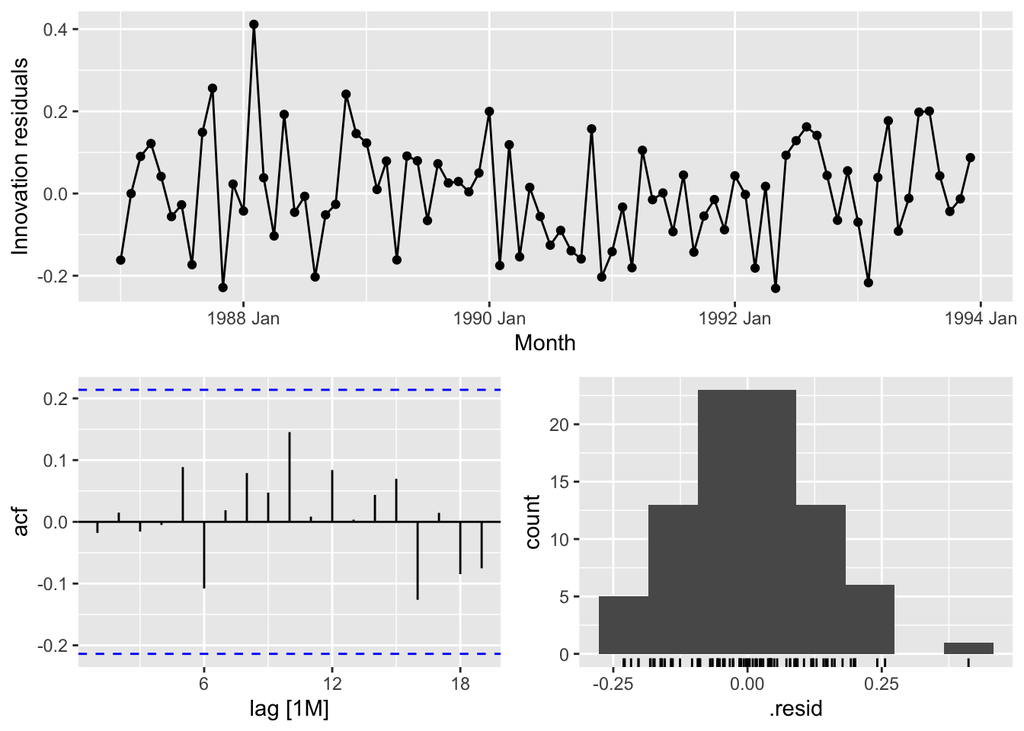

```r
fit |>
  select(dynreg) |>
  gg_tsresiduals()
```

These look fine.

# fpp3 10.7, Ex 4

> This exercise concerns `aus_accommodation`: the total quarterly takings from accommodation and the room occupancy level for hotels, motels, and guest houses in Australia, between January 1998 and June 2016. Total quarterly takings are in millions of Australian dollars. a. Compute the CPI-adjusted takings and plot the result for each state

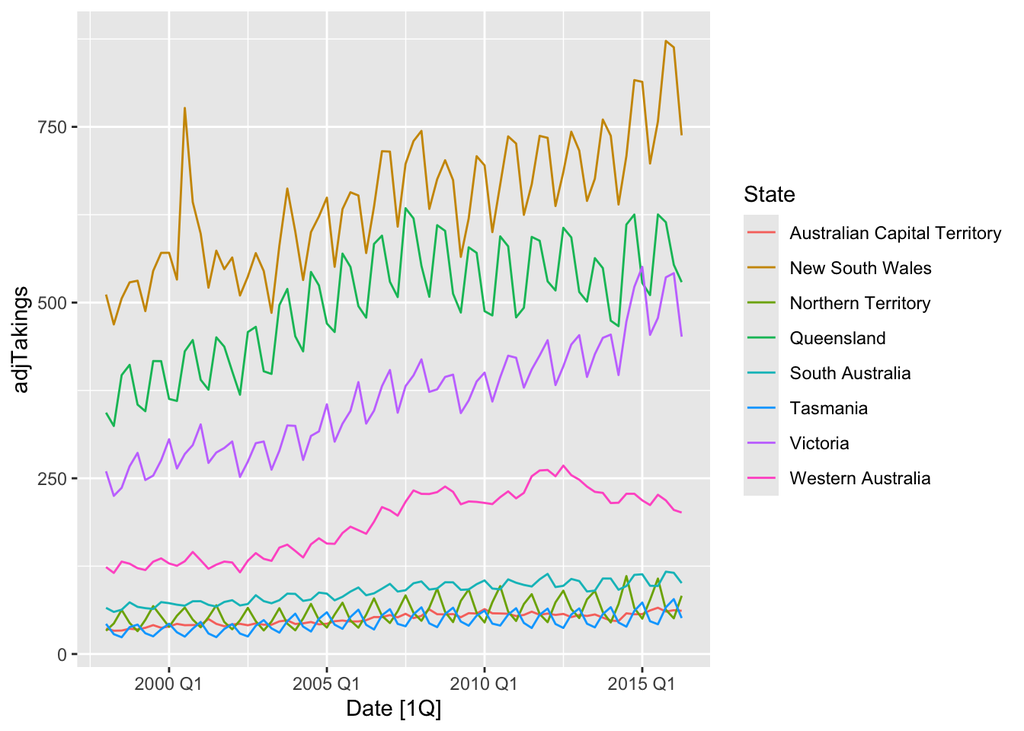

```r
aus_accommodation <- aus_accommodation |>
  mutate(
    adjTakings = Takings / CPI * 100
  )
aus_accommodation |>
  autoplot(adjTakings)
```

> 2. For each state, fit a dynamic regression model of CPI-adjusted takings with seasonal dummy variables, a piecewise linear time trend with one knot at 2008 Q1, and ARIMA errors.

```r
fit <- aus_accommodation |>
  model(
    ARIMA(adjTakings ~ season() + trend(knot = yearquarter("2008 Q1")))
  )
fit
```

```
# A mable: 8 x 2
# Key:     State [8]
  State                        ARIMA(adjTakings ~ season() + trend(knot = year…¹
  <chr>                                                                  <model>
1 Australian Capital Territory                       <LM w/ ARIMA(1,0,0) errors>
2 New South Wales                          <LM w/ ARIMA(1,0,0)(0,0,1)[4] errors>
3 Northern Territory                       <LM w/ ARIMA(0,0,1)(1,0,0)[4] errors>
4 Queensland                               <LM w/ ARIMA(1,0,0)(0,0,1)[4] errors>
5 South Australia                          <LM w/ ARIMA(1,0,0)(1,0,0)[4] errors>
6 Tasmania                                 <LM w/ ARIMA(0,0,1)(1,0,0)[4] errors>
7 Victoria                                 <LM w/ ARIMA(1,0,0)(0,0,1)[4] errors>
8 Western Australia                                  <LM w/ ARIMA(1,0,0) errors>
# ℹ abbreviated name:
#   ¹`ARIMA(adjTakings ~ season() + trend(knot = yearquarter("2008 Q1")))`
```

The seasonal dummy variable has not adequately handled the seasonality, so there are seasonal ARIMA components.

> 3. Check that the residuals of the model look like white noise.

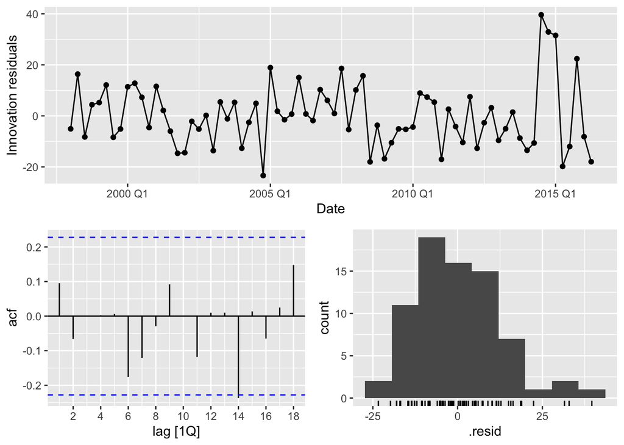

```r
fit |>
  filter(State == "Victoria") |>
  gg_tsresiduals()
```

No apparent problems. Similar plots needed for the other states.

> 4. Forecast the takings for each state to the end of 2017. (Hint: You will need to produce forecasts of the CPI first.)

```r
# CPI forecasts
cpif <- aus_accommodation |>
  model(ARIMA(CPI)) |>
  forecast(h = 6) |>
  as_tsibble() |>
  select(Date, State, CPI = .mean)
fit |>
  forecast(new_data = cpif) |>
  mutate(Takings = adjTakings * CPI / 100)
```

```
# A fable: 48 x 7 [1Q]
# Key:     State, .model [8]
   State                        .model                                      Date
   <chr>                        <chr>                                      <qtr>
 1 Australian Capital Territory "ARIMA(adjTakings ~ season() + trend(kn… 2016 Q3
 2 Australian Capital Territory "ARIMA(adjTakings ~ season() + trend(kn… 2016 Q4
 3 Australian Capital Territory "ARIMA(adjTakings ~ season() + trend(kn… 2017 Q1
 4 Australian Capital Territory "ARIMA(adjTakings ~ season() + trend(kn… 2017 Q2
 5 Australian Capital Territory "ARIMA(adjTakings ~ season() + trend(kn… 2017 Q3
 6 Australian Capital Territory "ARIMA(adjTakings ~ season() + trend(kn… 2017 Q4
 7 New South Wales              "ARIMA(adjTakings ~ season() + trend(kn… 2016 Q3
 8 New South Wales              "ARIMA(adjTakings ~ season() + trend(kn… 2016 Q4
 9 New South Wales              "ARIMA(adjTakings ~ season() + trend(kn… 2017 Q1
10 New South Wales              "ARIMA(adjTakings ~ season() + trend(kn… 2017 Q2
# ℹ 38 more rows
# ℹ 4 more variables: adjTakings <dist>, .mean <dbl>, CPI <dbl>, Takings <dist>
```

> 5. What sources of uncertainty have not been taken into account in the prediction intervals?
- The uncertainty in the CPI forecasts has been ignored.
- As usual, the estimation of the parameters and the choice of models have also not been accounted for.

# fpp3 10.7, Ex 5

> We fitted a harmonic regression model to part of the `us_gasoline` series in Exercise 6 in Section 7.10. We will now revisit this model, and extend it to include more data and ARMA errors.
> 1. Using `TSLM()`, fit a harmonic regression with a piecewise linear time trend to the full `gasoline` series. Select the position of the knots in the trend and the appropriate number of Fourier terms to include by minimising the AICc or CV value.

Let’s optimize using 2 break points and an unknown number of Fourier terms. Because the number of Fourier terms is integer, we can’t just use `optim`. Instead, we will loop over a large number of possible values for the breakpoints and Fourier terms. There are more than 2000 models fitted here, but `TSLM` is relatively fast.

Note that the possible values of the knots must be restricted so that knot2 is always much larger than knot1. We have set them to be at least 2 years apart here.

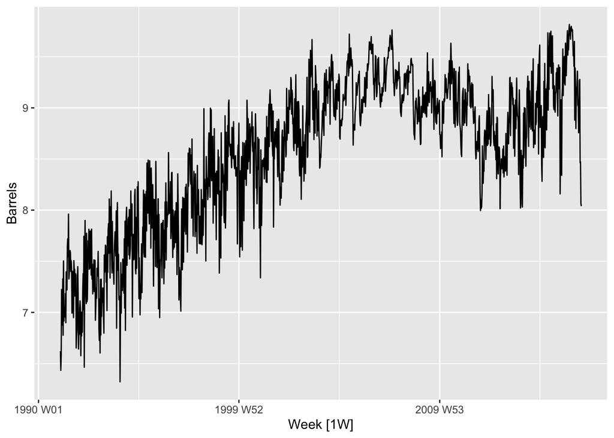

```r
us_gasoline |> autoplot(Barrels)
```

```r
# Function to compute CV given K and knots.
get_cv <- function(K, knot1, knot2) {
  us_gasoline |>
    model(TSLM(Barrels ~ fourier(K = K) + trend(c(knot1, knot2)))) |>
    glance() |>
    pull(CV)
}

models <- expand.grid(
  K = seq(25),
  knot1 = yearweek(as.character(seq(1991, 2017, 2))),
  knot2 = yearweek(as.character(seq(1991, 2017, 2)))
) |>
  filter(knot2 - knot1 > 104) |>
  as_tibble()
models <- models |>
  mutate(cv = purrr::pmap_dbl(models, get_cv)) |>
  arrange(cv)

# Best combination
(best <- head(models, 1))
```

```
# A tibble: 1 × 4
      K    knot1    knot2     cv
  <int>   <week>   <week>  <dbl>
1     6 2007 W01 2013 W01 0.0641
```

```r
fit <- us_gasoline |>
  model(
    TSLM(Barrels ~ fourier(K = best$K) + trend(c(best$knot1, best$knot2)))
  )
```

> 2. Now refit the model using `ARIMA()` to allow for correlated errors, keeping the same predictor variables as you used with `TSLM()`.

```r
fit <- us_gasoline |>
  model(ARIMA(Barrels ~ fourier(K = best$K) + trend(c(best$knot1, best$knot2)) + PDQ(0, 0, 0)))
fit |> report()
```

```
Series: Barrels
Model: LM w/ ARIMA(1,0,1) errors

Coefficients:
         ar1      ma1  fourier(K = best$K)C1_52  fourier(K = best$K)S1_52
      0.9277  -0.8414                   -0.1144                   -0.2306
s.e.  0.0256   0.0357                    0.0133                    0.0132
      fourier(K = best$K)C2_52  fourier(K = best$K)S2_52
                        0.0418                    0.0309
s.e.                    0.0105                    0.0105
      fourier(K = best$K)C3_52  fourier(K = best$K)S3_52
                        0.0836                    0.0343
s.e.                    0.0097                    0.0097
      fourier(K = best$K)C4_52  fourier(K = best$K)S4_52
                        0.0187                    0.0399
s.e.                    0.0094                    0.0094
      fourier(K = best$K)C5_52  fourier(K = best$K)S5_52
                       -0.0315                    0.0011
s.e.                    0.0092                    0.0092
      fourier(K = best$K)C6_52  fourier(K = best$K)S6_52
                       -0.0523                    0.0001
s.e.                    0.0092                    0.0092
      trend(c(best$knot1, best$knot2))trend
                                     0.0028
s.e.                                 0.0001
      trend(c(best$knot1, best$knot2))trend_831
                                        -0.0051
s.e.                                     0.0002
      trend(c(best$knot1, best$knot2))trend_1144  intercept
                                          0.0055     7.1065
s.e.                                      0.0006     0.0352

sigma^2 estimated as 0.06051:  log likelihood=-13.38
AIC=64.76   AICc=65.33   BIC=163.78
```

> 3. Check the residuals of the final model using the `gg_tsdisplay()` function and a Ljung-Box test. Do they look sufficiently like white noise to continue? If not, try modifying your model, or removing the first few years of data.

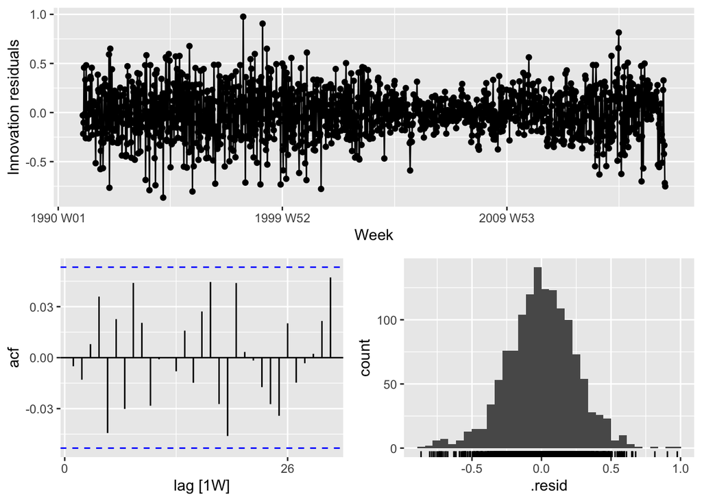

```r
gg_tsresiduals(fit)
```

```r
augment(fit) |> features(.innov, ljung_box, dof = 2, lag = 26)
```

```
# A tibble: 1 × 3
  .model                                                       lb_stat lb_pvalue
  <chr>                                                          <dbl>     <dbl>
1 "ARIMA(Barrels ~ fourier(K = best$K) + trend(c(best$knot1, …    25.8     0.365
```

Usually, we choose `lag` to be twice the seasonal period, but the seasonal period here is about 52, and 104 lags is too many for the test statistics to have good properties. So we’ve set `lag` to be 26 which should be plenty.

The model looks pretty good, and passes the Ljung-Box test, although there is some heteroskedasticity.

> 4. Once you have a model with white noise residuals, produce forecasts for the next year.

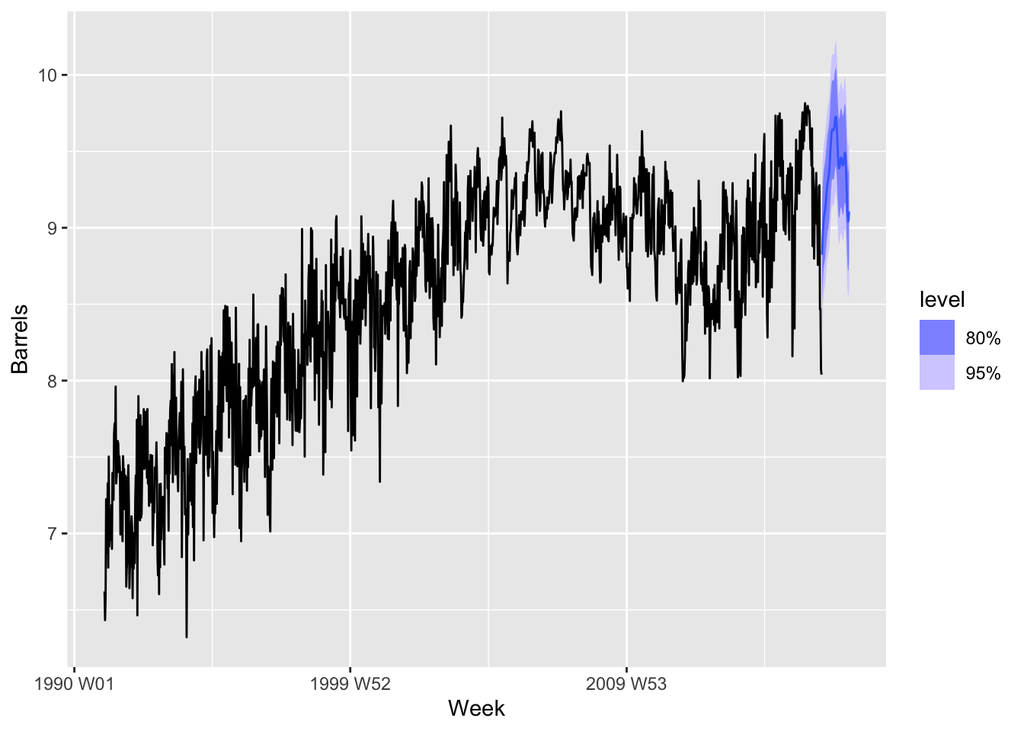

```r
fit |>
  forecast(h = "1 year") |>
  autoplot(us_gasoline)
```

# fpp3 10.7, Ex 6

> Electricity consumption is often modelled as a function of temperature. Temperature is measured by daily heating degrees and cooling degrees. Heating degrees is $18^\circ$C minus the average daily temperature when the daily average is below $18^\circ$C; otherwise it is zero. This provides a measure of our need to heat ourselves as temperature falls. Cooling degrees measures our need to cool ourselves as the temperature rises. It is defined as the average daily temperature minus $18^\circ$C when the daily average is above $18^\circ$C; otherwise it is zero. Let $y_t$ denote the monthly total of kilowatt-hours of electricity used, let $x_{1,t}$ denote the monthly total of heating degrees, and let $x_{2,t}$ denote the monthly total of cooling degrees.

> An analyst fits the following model to a set of such data:
> $$y^*_t = \beta_1x^*_{1,t} + \beta_2x^*_{2,t} + \eta_t,$$
> where
> $$(1-\Phi_{1}B^{12} - \Phi_{2}B^{24})(1-B)(1-B^{12})\eta_t = (1+\theta_1 B)\varepsilon_t$$
> and $y^*_t = \log(y_t)$, $x^*_{1,t} = \sqrt{x_{1,t}}$ and $x^*_{2,t}=\sqrt{x_{2,t}}$.
> 1. What sort of ARIMA model is identified for $\eta_t$?

ARIMA(0,1,1)(2,1,0)$_{12}$

> 2. The estimated coefficients are

> | Parameter | Estimate | s.e. | $Z$ | $P$-value |
> | --- | --- | --- | --- | --- |
> | $\beta_1$ | 0.0077 | 0.0015 | 4.98 | 0.000 |
> | $\beta_2$ | 0.0208 | 0.0023 | 9.23 | 0.000 |
> | $\theta_1$ | 0.5830 | 0.0720 | 8.10 | 0.000 |
> | $\Phi_{1}$ | -0.5373 | 0.0856 | -6.27 | 0.000 |
> | $\Phi_{2}$ | -0.4667 | 0.0862 | -5.41 | 0.000 |

> Explain what the estimates of $\beta_1$ and $\beta_2$ tell us about electricity consumption.

$\beta_1$ is the unit increase in $y_t^*$ when $x_{1,t}^*$ increases by 1. This is a little hard to interpret, but it is clear that monthly total electricity usage goes up when monthly heating degrees goes up. Similarly, for $\beta_2$, monthly total electricity usage goes up when monthly cooling degrees goes up.

> 3. Write the equation in a form more suitable for forecasting.

This turned out to be way more messy than I expected, but for what it’s worth, here it is in all its ugliness.

First apply the differences to the regression equation.
$$(1-B)(1-B^{12}) y_t^* = \beta_1^*(1-B)(1-B^{12})x_{1,t}^* + \beta_2^*(1-B)(1-B^{12})x_{2,t}^* + (1-B)(1-B^{12})\eta_{t}$$
So
$$(y^*_{t} - y^*_{t-1} - y^*_{t-12} +y^*_{t-13})
= \beta_1(x^*_{1,t} - x^*_{1,t-1} - x^*_{1,t-12} + x^*_{1,t-13})
+ \beta_2(x^*_{2,t} - x^*_{2,t-1} - x^*_{2,t-12} + x^*_{2,t-13}) + \eta'_t$$
Multiplying by the AR polynomial gives
$$\begin{align*}
(y^*_{t} & - y^*_{t-1} - y^*_{t-12} +y^*_{t-13})
-\Phi_{1}(y^*_{t-12} - y^*_{t-13} - y^*_{t-24} +y^*_{t-25})
-\Phi_{2}(y^*_{t-24} - y^*_{t-25} - y^*_{t-36} +y^*_{t-37})\\
= & ~ \beta_1(x^*_{1,t} - x^*_{1,t-1} - x^*_{1,t-12} + x^*_{1,t-13})
-\Phi_{1}\beta_1(x^*_{1,t-12} - x^*_{1,t-13} - x^*_{1,t-24} + x^*_{1,t-25})
-\Phi_{2}\beta_1(x^*_{1,t-24} - x^*_{1,t-25} - x^*_{1,t-36} + x^*_{1,t-37}) \\
& + \beta_2(x^*_{2,t} - x^*_{2,t-1} - x^*_{2,t-12} + x^*_{2,t-13})
- \Phi_{1}\beta_2(x^*_{2,t-12} - x^*_{2,t-13} - x^*_{2,t-24} + x^*_{2,t-25})
- \Phi_{2}\beta_2(x^*_{2,t-24} - x^*_{2,t-25} - x^*_{2,t-36} + x^*_{2,t-37}) \\
& + \varepsilon_t + \theta_1 \varepsilon_{t-1}.
\end{align*}$$
Finally, we move all but $y_t^*$ to the right hand side:
$$\begin{align*}
y^*_{t} = & ~ y^*_{t-1} + y^*_{t-12} - y^*_{t-13}
+\Phi_{1}(y^*_{t-12} - y^*_{t-13} - y^*_{t-24} +y^*_{t-25})
+\Phi_{2}(y^*_{t-24} - y^*_{t-25} - y^*_{t-36} +y^*_{t-37})\\
& + \beta_1(x^*_{1,t} - x^*_{1,t-1} - x^*_{1,t-12} + x^*_{1,t-13})
-\Phi_{1}\beta_1(x^*_{1,t-12} - x^*_{1,t-13} - x^*_{1,t-24} + x^*_{1,t-25})
-\Phi_{2}\beta_1(x^*_{1,t-24} - x^*_{1,t-25} - x^*_{1,t-36} + x^*_{1,t-37}) \\
& + \beta_2(x^*_{2,t} - x^*_{2,t-1} - x^*_{2,t-12} + x^*_{2,t-13})
- \Phi_{1}\beta_2(x^*_{2,t-12} - x^*_{2,t-13} - x^*_{2,t-24} + x^*_{2,t-25})
- \Phi_{2}\beta_2(x^*_{2,t-24} - x^*_{2,t-25} - x^*_{2,t-36} + x^*_{2,t-37}) \\
& + \varepsilon_t + \theta_1 \varepsilon_{t-1}.
\end{align*}$$

> 4. Describe how this model could be used to forecast electricity demand for the next 12 months.

For $t=T+1$, we use the above equation to find a point forecast of $y_{T+1}^*$, setting $\varepsilon_{T+1}=0$ and $\hat{\varepsilon}_T$ to the last residual. The actual $y_t^*$ values are all known, as are all the $x_{1,t}^*$ and $x_{2,t}^*$ values up to time $t=T$. For $x_{1,T+1}^*$ and $x_{2,T+1}^*$, we could use a forecast (for example, a seasonal naive forecast).

For $t=T+2,\dots,T+12$, we do something similar, but both $\varepsilon$ values are set to 0 and $y^*_{T+k}$ ($k\ge1$) is replaced by the forecasts just calculated.

> 5. Explain why the $\eta_t$ term should be modelled with an ARIMA model rather than modelling the data using a standard regression package. In your discussion, comment on the properties of the estimates, the validity of the standard regression results, and the importance of the $\eta_t$ model in producing forecasts.
- The non-stationarity of $\eta_t$ means the coefficients in the regression model will be inconsistent if OLS is used.
- The standard errors will be incorrectly computed.
- Which means all the p-values will be wrong.
- Using an ARIMA structure for $\eta_t$ allows these problems to be corrected, plus the short-term forecasts will be more accurate.

# fpp3 10.7, Ex 7

> For the retail time series considered in earlier chapters:
> 1. Develop an appropriate dynamic regression model with Fourier terms for the seasonality. Use the AIC to select the number of Fourier terms to include in the model. (You will probably need to use the same Box-Cox transformation you identified previously.)

```r
set.seed(12345678)
myseries <- aus_retail |>
  filter(
    `Series ID` == sample(aus_retail$`Series ID`, 1),
    Month < yearmonth("2018 Jan")
  )

myseries |> features(Turnover, guerrero)
```

```
# A tibble: 1 × 3
  State              Industry                                    lambda_guerrero
  <chr>              <chr>                                                 <dbl>
1 Northern Territory Clothing, footwear and personal accessory …          0.0776
```

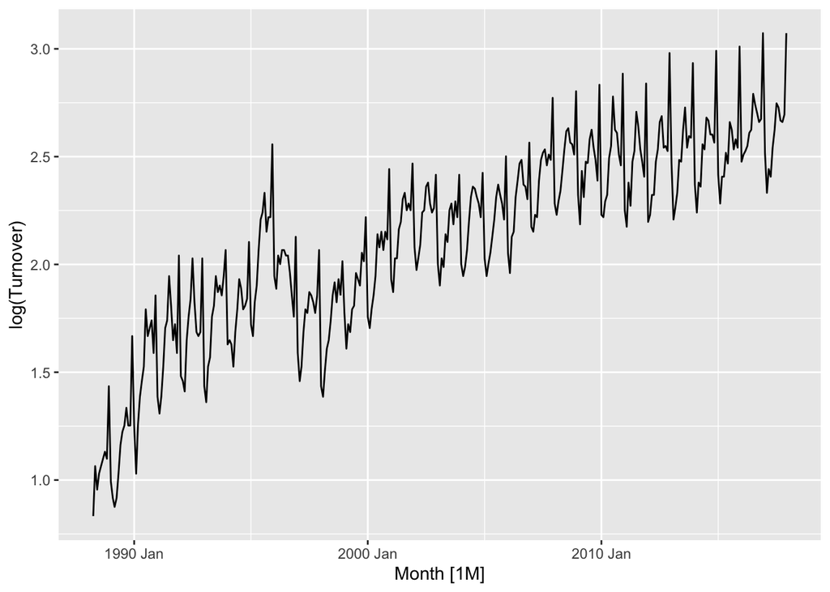

```r
myseries |> autoplot(log(Turnover))
```

```r
fit <- myseries |>
  model(
    `K=1` = ARIMA(log(Turnover) ~ trend() + fourier(K = 1) +
      pdq(0:2, 0, 0:2) + PDQ(0:1, 0, 0:1)),
    `K=2` = ARIMA(log(Turnover) ~ trend() + fourier(K = 2) +
      pdq(0:2, 0, 0:2) + PDQ(0:1, 0, 0:1)),
    `K=3` = ARIMA(log(Turnover) ~ trend() + fourier(K = 3) +
      pdq(0:2, 0, 0:2) + PDQ(0:1, 0, 0:1)),
    `K=4` = ARIMA(log(Turnover) ~ trend() + fourier(K = 4) +
      pdq(0:2, 0, 0:2) + PDQ(0:1, 0, 0:1)),
    `K=5` = ARIMA(log(Turnover) ~ trend() + fourier(K = 5) +
      pdq(0:2, 0, 0:2) + PDQ(0:1, 0, 0:1)),
    `K=6` = ARIMA(log(Turnover) ~ trend() + fourier(K = 6) +
      pdq(0:2, 0, 0:2) + PDQ(0:1, 0, 0:1))
  )
glance(fit)
```

```
# A tibble: 6 × 10
  State      Industry .model  sigma2 log_lik   AIC  AICc   BIC ar_roots ma_roots
  <chr>      <chr>    <chr>    <dbl>   <dbl> <dbl> <dbl> <dbl> <list>   <list>
1 Northern … Clothin… K=1    0.00664    383. -748. -748. -713. <cpl>    <cpl>
2 Northern … Clothin… K=2    0.00652    389. -756. -755. -713. <cpl>    <cpl>
3 Northern … Clothin… K=3    0.00626    400. -774. -773. -723. <cpl>    <cpl>
4 Northern … Clothin… K=4    0.00596    411. -792. -791. -734. <cpl>    <cpl>
5 Northern … Clothin… K=5    0.00480    453. -873. -872. -811. <cpl>    <cpl>
6 Northern … Clothin… K=6    0.00437    470. -906. -905. -841. <cpl>    <cpl>
```

Including 6 harmonics minimises the AICc (and AIC/BIC) for this series.

```r
fit <- transmute(fit, best = `K=6`)

report(fit)
```

```
Series: Turnover
Model: LM w/ ARIMA(1,0,1)(1,0,0)[12] errors
Transformation: log(Turnover)

Coefficients:
         ar1      ma1    sar1  trend()  fourier(K = 6)C1_12
      0.9632  -0.3755  0.1761   0.0041              -0.0809
s.e.  0.0165   0.0502  0.0542   0.0006               0.0080
      fourier(K = 6)S1_12  fourier(K = 6)C2_12  fourier(K = 6)S2_12
                  -0.1258               0.0381              -0.0882
s.e.               0.0080               0.0052               0.0052
      fourier(K = 6)C3_12  fourier(K = 6)S3_12  fourier(K = 6)C4_12
                  -0.0206              -0.0815              -0.0294
s.e.               0.0045               0.0045               0.0042
      fourier(K = 6)S4_12  fourier(K = 6)C5_12  fourier(K = 6)S5_12
                  -0.0538              -0.0554              -0.0540
s.e.               0.0042               0.0041               0.0041
      fourier(K = 6)C6_12  intercept
                  -0.0230     1.3317
s.e.               0.0029     0.1231

sigma^2 estimated as 0.004368:  log likelihood=470.23
AIC=-906.46   AICc=-904.65   BIC=-840.54
```

> 2. Check the residuals of the fitted model. Does the residual series look like white noise?

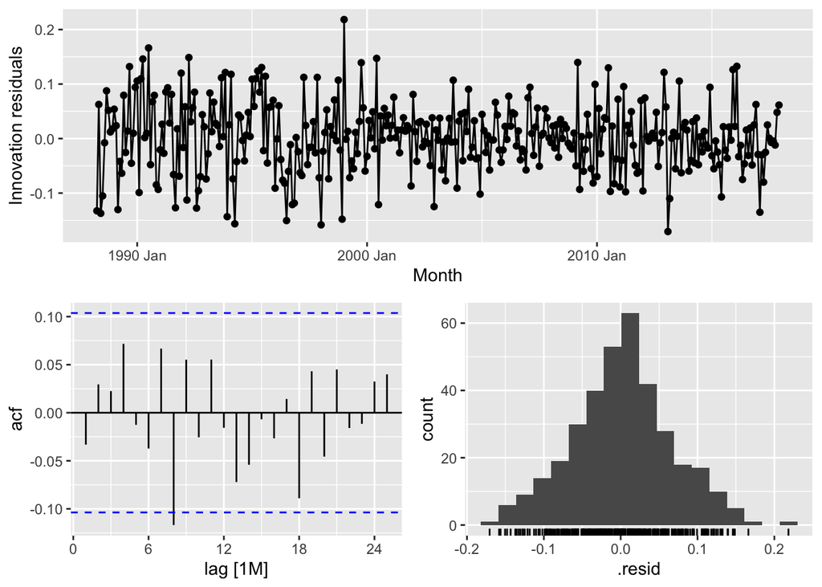

```r
gg_tsresiduals(fit)
```

The residuals look well behaved.

> 3. Compare the forecasts with those you obtained earlier using alternative models.

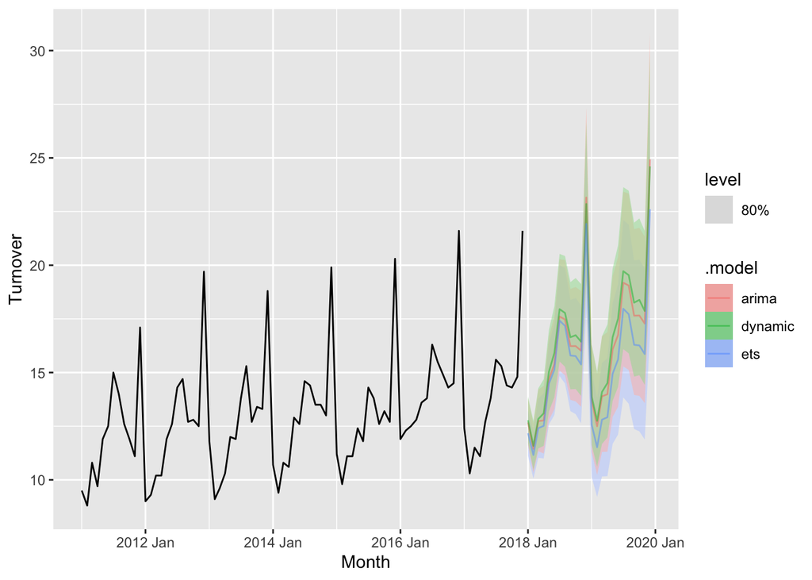

```r
fit <- myseries |>
  model(
    dynamic = ARIMA(log(Turnover) ~ trend() + fourier(K = 6) +
      pdq(0:2, 0, 0:2) + PDQ(0:1, 0, 0:1)),
    arima = ARIMA(log(Turnover)),
    ets = ETS(Turnover)
  )
fit |>
  forecast() |>
  autoplot(filter(myseries, year(Month) > 2010), level = 80, alpha = 0.5)
```